# Honey production data

### Data Visualization on Honey Production dataset using seaborn and matplotlib libraries.

1. Import required libraries and read the dataset.

```python
import numpy as np
import pandas as pd
import matplotlib.pyplot as plt
import seaborn as sns
```

```python
df=pd.read_csv("honeyproduction.csv")
```

```python
df
```

|  | state | numcol | yieldpercol | totalprod | stocks | priceperlb | prodvalue | year |
| --- | --- | --- | --- | --- | --- | --- | --- | --- |
| 0 | AL | 16000.0 | 71 | 1136000.0 | 159000.0 | 0.72 | 818000.0 | 1998 |
| 1 | AZ | 55000.0 | 60 | 3300000.0 | 1485000.0 | 0.64 | 2112000.0 | 1998 |
| 2 | AR | 53000.0 | 65 | 3445000.0 | 1688000.0 | 0.59 | 2033000.0 | 1998 |
| 3 | CA | 450000.0 | 83 | 37350000.0 | 12326000.0 | 0.62 | 23157000.0 | 1998 |
| 4 | CO | 27000.0 | 72 | 1944000.0 | 1594000.0 | 0.70 | 1361000.0 | 1998 |
| ... | ... | ... | ... | ... | ... | ... | ... | ... |
| 621 | VA | 4000.0 | 41 | 164000.0 | 23000.0 | 3.77 | 618000.0 | 2012 |
| 622 | WA | 62000.0 | 41 | 2542000.0 | 1017000.0 | 2.38 | 6050000.0 | 2012 |
| 623 | WV | 6000.0 | 48 | 288000.0 | 95000.0 | 2.91 | 838000.0 | 2012 |
| 624 | WI | 60000.0 | 69 | 4140000.0 | 1863000.0 | 2.05 | 8487000.0 | 2012 |
| 625 | WY | 50000.0 | 51 | 2550000.0 | 459000.0 | 1.87 | 4769000.0 | 2012 |

626 rows × 8 columns

2. Check the first few samples, shape, info of the data and try to familiarize yourself with different features

```python
df.head(40)
```

|  | state | numcol | yieldpercol | totalprod | stocks | priceperlb | prodvalue | year |
| --- | --- | --- | --- | --- | --- | --- | --- | --- |
| 0 | AL | 16000.0 | 71 | 1136000.0 | 159000.0 | 0.72 | 818000.0 | 1998 |
| 1 | AZ | 55000.0 | 60 | 3300000.0 | 1485000.0 | 0.64 | 2112000.0 | 1998 |
| 2 | AR | 53000.0 | 65 | 3445000.0 | 1688000.0 | 0.59 | 2033000.0 | 1998 |
| 3 | CA | 450000.0 | 83 | 37350000.0 | 12326000.0 | 0.62 | 23157000.0 | 1998 |
| 4 | CO | 27000.0 | 72 | 1944000.0 | 1594000.0 | 0.70 | 1361000.0 | 1998 |
| 5 | FL | 230000.0 | 98 | 22540000.0 | 4508000.0 | 0.64 | 14426000.0 | 1998 |
| 6 | GA | 75000.0 | 56 | 4200000.0 | 307000.0 | 0.69 | 2898000.0 | 1998 |
| 7 | HI | 8000.0 | 118 | 944000.0 | 66000.0 | 0.77 | 727000.0 | 1998 |
| 8 | ID | 120000.0 | 50 | 6000000.0 | 2220000.0 | 0.65 | 3900000.0 | 1998 |
| 9 | IL | 9000.0 | 71 | 639000.0 | 204000.0 | 1.19 | 760000.0 | 1998 |
| 10 | IN | 9000.0 | 92 | 828000.0 | 489000.0 | 0.85 | 704000.0 | 1998 |
| 11 | IA | 50000.0 | 78 | 3900000.0 | 2301000.0 | 0.70 | 2730000.0 | 1998 |
| 12 | KS | 16000.0 | 46 | 736000.0 | 390000.0 | 0.87 | 640000.0 | 1998 |
| 13 | KY | 3000.0 | 50 | 150000.0 | 51000.0 | 1.40 | 210000.0 | 1998 |
| 14 | LA | 41000.0 | 111 | 4551000.0 | 865000.0 | 0.59 | 2685000.0 | 1998 |
| 15 | ME | 10000.0 | 26 | 260000.0 | 117000.0 | 0.69 | 179000.0 | 1998 |
| 16 | MD | 7000.0 | 44 | 308000.0 | 92000.0 | 1.10 | 339000.0 | 1998 |
| 17 | MI | 80000.0 | 85 | 6800000.0 | 3672000.0 | 0.66 | 4488000.0 | 1998 |
| 18 | MN | 140000.0 | 79 | 11060000.0 | 2765000.0 | 0.65 | 7189000.0 | 1998 |
| 19 | MS | 18000.0 | 86 | 1548000.0 | 898000.0 | 0.58 | 898000.0 | 1998 |
| 20 | MO | 23000.0 | 66 | 1518000.0 | 455000.0 | 0.76 | 1154000.0 | 1998 |
| 21 | MT | 115000.0 | 122 | 14030000.0 | 5472000.0 | 0.64 | 8979000.0 | 1998 |
| 22 | NE | 64000.0 | 70 | 4480000.0 | 2240000.0 | 0.86 | 3853000.0 | 1998 |
| 23 | NV | 10000.0 | 46 | 460000.0 | 175000.0 | 1.65 | 759000.0 | 1998 |
| 24 | NJ | 11000.0 | 49 | 539000.0 | 167000.0 | 0.76 | 410000.0 | 1998 |
| 25 | NM | 14000.0 | 55 | 770000.0 | 470000.0 | 0.76 | 585000.0 | 1998 |
| 26 | NY | 65000.0 | 80 | 5200000.0 | 2444000.0 | 0.70 | 3640000.0 | 1998 |
| 27 | NC | 8000.0 | 59 | 472000.0 | 151000.0 | 1.38 | 651000.0 | 1998 |
| 28 | ND | 230000.0 | 128 | 29440000.0 | 8832000.0 | 0.63 | 18547000.0 | 1998 |
| 29 | OH | 18000.0 | 78 | 1404000.0 | 702000.0 | 0.83 | 1165000.0 | 1998 |
| 30 | OK | 4000.0 | 51 | 204000.0 | 63000.0 | 1.24 | 253000.0 | 1998 |
| 31 | OR | 50000.0 | 45 | 2250000.0 | 1620000.0 | 0.90 | 2025000.0 | 1998 |
| 32 | PA | 26000.0 | 66 | 1716000.0 | 789000.0 | 0.80 | 1373000.0 | 1998 |
| 33 | SD | 225000.0 | 95 | 21375000.0 | 10901000.0 | 0.64 | 13680000.0 | 1998 |
| 34 | TN | 7000.0 | 64 | 448000.0 | 121000.0 | 1.32 | 591000.0 | 1998 |
| 35 | TX | 91000.0 | 77 | 7007000.0 | 1612000.0 | 0.62 | 4344000.0 | 1998 |
| 36 | UT | 30000.0 | 58 | 1740000.0 | 557000.0 | 0.65 | 1131000.0 | 1998 |
| 37 | VT | 6000.0 | 64 | 384000.0 | 207000.0 | 0.85 | 326000.0 | 1998 |
| 38 | VA | 8000.0 | 37 | 296000.0 | 86000.0 | 1.33 | 394000.0 | 1998 |
| 39 | WA | 58000.0 | 51 | 2958000.0 | 1361000.0 | 0.64 | 1893000.0 | 1998 |

```python
df.shape
```

```
(626, 8)
```

```python
df.info()
```

```
<class 'pandas.core.frame.DataFrame'>
RangeIndex: 626 entries, 0 to 625
Data columns (total 8 columns):
 #   Column       Non-Null Count  Dtype
---  ------       --------------  -----
 0   state        626 non-null    object
 1   numcol       626 non-null    float64
 2   yieldpercol  626 non-null    int64
 3   totalprod    626 non-null    float64
 4   stocks       626 non-null    float64
 5   priceperlb   626 non-null    float64
 6   prodvalue    626 non-null    float64
 7   year         626 non-null    int64
dtypes: float64(5), int64(2), object(1)
memory usage: 39.3+ KB
```

3. Display the percentage distribution of the data in each year using the pie chart.

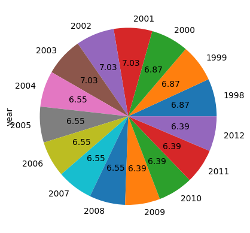

```python
df.groupby(by='year')['year'].count().plot(kind='pie',autopct='%.2f');
```

4. Plot and Understand the distribution of the variable "price per lb" using displot, and write your findings.

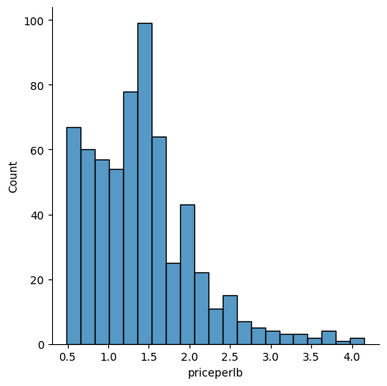

```python
sns.displot(x=df['priceperlb'],kind='hist');
```

- The distribution of variable 'priceperlb' is positively skewed where more data is clustered at the start of distribution
- The distribution of variable 'priceperlb' has the highest peakedness at 1.5

5. Plot and understand the relationship between the variables 'numcol' and 'prodvalue' through scatterplot, and write your findings.

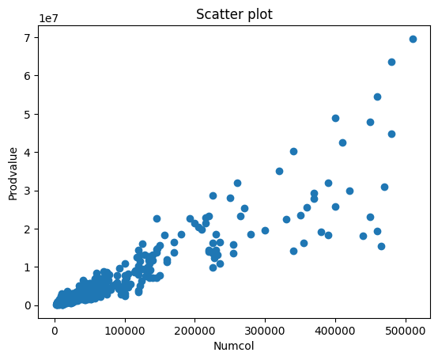

```python
plt.scatter(x=df['numcol'],y=df['prodvalue']);
plt.title('Scatter plot');
plt.xlabel('Numcol');
plt.ylabel('Prodvalue');
```

- Most of the data are clustered between 200000 numcol and prodvalue 2
- Whereas the outliers lie above 400000 numcol and prodvalue 5

6. Plot and understand the relationship between categorical variable 'year' and a numerical variable 'prodvalue' through boxplot, and write your findings.

```python
import plotly.express as px
px.box(x=df['year'],y=df['prodvalue'])
```

[interactive chart not shown]

- Every year has been affected by the extreme values and has outliers
- The Even years does have less outliers ccomparing to the odd years.

7. Visualize and understand the relationship between the multiple pairs of variables throughout different years using pairplot and add your inferences. (use columns 'numcol', 'yield percol', 'total prod', 'prodvalue','year')

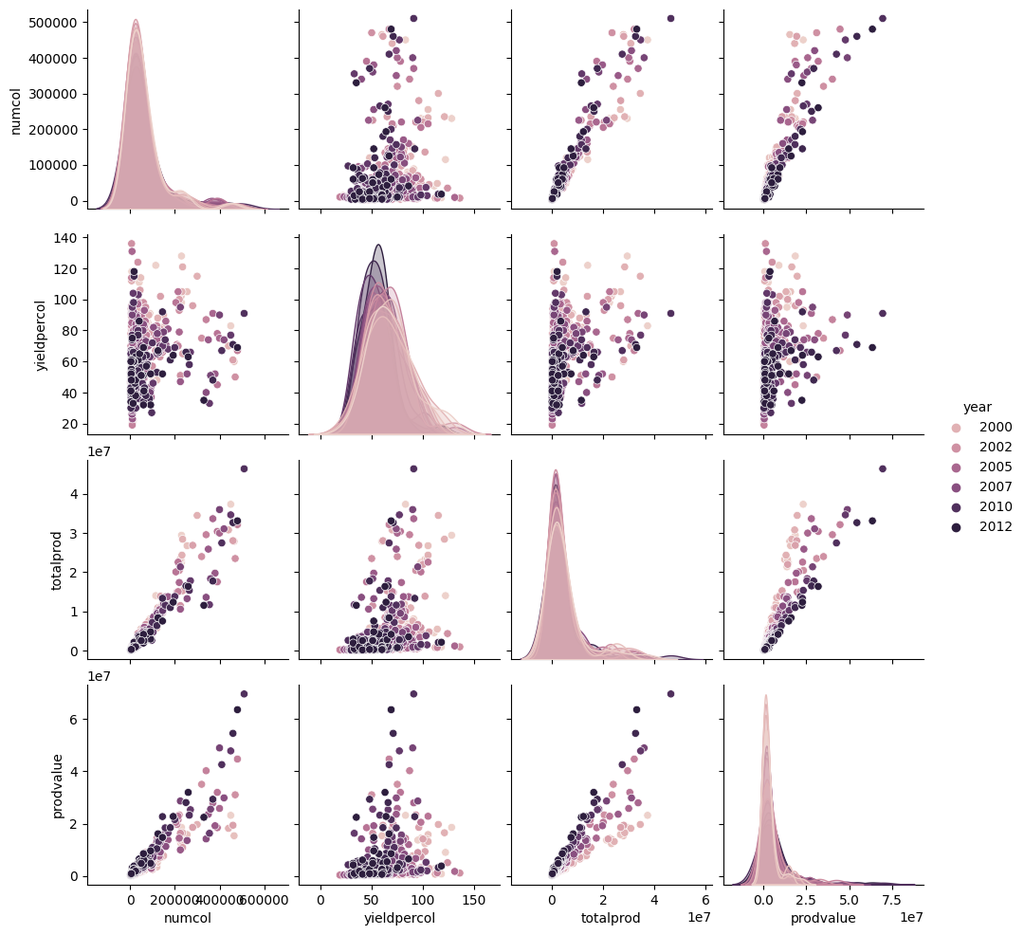

```python
sns.pairplot(df[['numcol', 'yieldpercol', 'totalprod', 'prodvalue','year']],hue='year');
```

- The variables numcol,yieldpercol,totalprod and prodvalue are positively skewed comparing to the years
- The variables numcol,yieldpercol,totalprod and prodvalue are leptokertic.
- The variables numcol,prodvalue and totalprod does have linear relationship.

8. Display the correlation values using a plot and add your inferences. (use columns 'numcol', 'yield percol','total prod', 'stocks', 'price per lb', 'prodvalue')

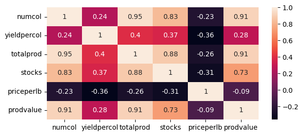

```python
plt.figure(figsize=(7,3))
sns.heatmap(df[['numcol', 'yieldpercol','totalprod', 'stocks', 'priceperlb', 'prodvalue']].corr(),annot=True,cbar=True);
```

- The variable priceperlb is negatively correlated to other variables

so they are inversely proportional to each other

- The variables numcol and totalprod has high correlation 95% and variables prodvalue,numcol and total prod have high correlation of 91%